# CENT LC analysis

Ben Cowley

19/05/2017

# LC Analysis report

Aim of the approach is to quantify aspects or respresentations of learning (termed simply ‘LCs’ below) so that we can examine in more detail the relationship between patient’s clinical activity and treatment outcome.

We use a fairly constrained definition of LC, as: *the demonstrated performance on a trial-to-trial basis in the specific task expicitly required of the patient*.

### What LCs are not

We will distinguish task-learning from task-outcomes, even when such outcomes are measured repeatedly throughout the training, such as baseline bandpowers or repeated symptom self-reports. We will also not look at trial-wise changes in individual bandpowers, because the “*specific task expicitly required of the patient*” is to change **two** bandpowers at the same time (also such data would require more EEG preprocessing, but we won’t report that reason ;).

### What LCs are

We will study the LCs representing the following aspects of learning:

- learning *gain*: how much learning happened = how much the performance score went up (growth curve model)
- *sufficient* learning: how many sessions were required to learn = where is the plateau point inside a fixed number of sessions (quadratic fit)
- *monotonic* learning: how probably do scores rise or fall monotonically, measured by:
  - session-wise rank-correlation of scores with order, *cor(S, O)*
  - aggregate over all sessions of: rank-correlation of trial scores with order, *A(S, cor(T, O))*
  - aggregate of both above
- *ideal* learning: how consistent is observed trial-wise score correlation with ‘ideal’ learning. Measured by cosine similarity of trial-wise rank correlations to a hypothetical optimal learning curve derived from learning theory (Fitt’s model)

[ *Names of LCs are arbitrary - some review of education literature might be required!* ]

The results in draft paper “Learning Curves_v02.docx” show quantification for *gain* and *sufficiency*, where session-wise scores were fitted with linear (growth curve) and quadratic models.

These two LC concepts are the main focus of prior work on NFB learning. When studies estimate whether subjects have learned, they usually calculate *gain* in some way (REF). Several studies have also estimated *sufficiency* by looking at the number of sessions required to see a plateau in improvement (REF).

However, such fitted models are very sensitive to small changes in the data: outliers can change the linear-fit slope or the curvature of the quadratic fit by significant amounts. Thus it is valuable to also look at LCs that are model-free, i.e. non-parametric.

Our *monotonic* and *ideal* LCs address this issue, and provide clear and easy-to-interpret models of learning.

### Summary

Our analysis approach is thus to use the derived LCs to discover group-wise patterns in the various background and outcome variables available, in a within-subjects manner.

In the rest of the report, we will step through the methods for creating *monotonic*, and *ideal* LCs to see how they work. We will then explore the relationships with background and outcome variables. First, we describe the data used.

## Data

We work primarily from the following datasets (available in shared Dropbox folder or on request):

- auto_block.csv - *trial-wise scores, game-types, and date-time values*
- test_outcomes.csv - *per-subject values for background, test outcomes, and self-reports*
- meta_data.csv - *aggregate values for all sessions in NFB training*

We filter trials to clean the dataset, removing the first session (as it was a training session), trials with score = 0, and trials marked bad by trainers.

```
## [1] "Data: tr.raw$adj_score"
##    Min. 1st Qu.  Median    Mean 3rd Qu.    Max.
##   -2.25   10.17   15.59   16.68   22.25   87.24
## [1] "... subset:  TB"
##    Min. 1st Qu.  Median    Mean 3rd Qu.    Max.
##   -1.20   12.29   19.92   20.34   27.26   87.24
## [1] "... subset:  SMR"
##    Min. 1st Qu.  Median    Mean 3rd Qu.    Max.
##   -2.25    9.53   14.22   14.88   19.52   68.90
```

```
## [1] "Data: tr.blk$adj_score"
##    Min. 1st Qu.  Median    Mean 3rd Qu.    Max.
##    0.00   12.64   17.08   19.03   23.51   72.96
## [1] "... subset:  TB"
##    Min. 1st Qu.  Median    Mean 3rd Qu.    Max.
##    0.16   16.95   22.00   23.70   29.08   72.96
## [1] "... subset:  SMR"
##    Min. 1st Qu.  Median    Mean 3rd Qu.    Max.
##    0.00   11.73   15.41   16.81   20.16   68.90
```

We also subset scores according to the three training modes (normal, inverse, transfer), so we have four (clean) datasets (further subdivided by subjects in TB protocol and subjects in SMR protocol):

- all trials
- normal trials
- inverse trials
- transfer trials

For each dataset we create a new index of sessions so that rows can be aligned according to how many sessions of a protocol were conducted, as opposed to what the session number was when starting. Thus, e.g. transfer trials are indexed from 1 to 10 for all subjects, regardless of what session it was that their transfer trials really started (first transfer trial ranged from session 28 to session 35, depending on subject).

```
## [1] "Data: trials$adj_score"
##    Min. 1st Qu.  Median    Mean 3rd Qu.    Max.
##    0.00   12.64   17.08   19.03   23.51   72.96
## [1] "... subset:  TB"
##    Min. 1st Qu.  Median    Mean 3rd Qu.    Max.
##    0.16   16.95   22.00   23.70   29.08   72.96
## [1] "... subset:  SMR"
##    Min. 1st Qu.  Median    Mean 3rd Qu.    Max.
##    0.00   11.73   15.41   16.81   20.16   68.90
```

```
## [1] "Data: tr.nor0$adj_score"
##    Min. 1st Qu.  Median    Mean 3rd Qu.    Max.
##    0.00   12.14   15.99   17.77   21.20   72.96
## [1] "... subset:  TB"
##    Min. 1st Qu.  Median    Mean 3rd Qu.    Max.
##    1.73   17.84   22.66   24.55   29.36   72.96
## [1] "... subset:  SMR"
##    Min. 1st Qu.  Median    Mean 3rd Qu.    Max.
##    0.00   11.02   14.16   14.52   17.44   50.37
```

```
## [1] "Data: tr.inv0$adj_score"
##    Min. 1st Qu.  Median    Mean 3rd Qu.    Max.
##    0.16   17.66   24.04   23.84   30.31   48.90
## [1] "... subset:  TB"
##    Min. 1st Qu.  Median    Mean 3rd Qu.    Max.
##    0.16   11.20   17.36   17.52   23.95   43.26
## [1] "... subset:  SMR"
##    Min. 1st Qu.  Median    Mean 3rd Qu.    Max.
##    5.14   21.50   27.10   26.91   32.20   48.90
```

```
## [1] "Data: tr.tra0$adj_score"
##    Min. 1st Qu.  Median    Mean 3rd Qu.    Max.
##    4.55   13.99   18.25   21.40   25.37   68.90
## [1] "... subset:  TB"
##    Min. 1st Qu.  Median    Mean 3rd Qu.    Max.
##    5.91   19.28   31.01   30.71   37.24   62.91
## [1] "... subset:  SMR"
##    Min. 1st Qu.  Median    Mean 3rd Qu.    Max.
##    4.55   12.79   16.36   17.42   20.87   68.90
```

We come across our first significant problem. For calculating trial-wise correlations, we require 2 or more trials per session. Many sessions contain only one trial of a certain type, especially for transfer trials. We therefore create datasets that prune out the sessions with trials = 1. We also face a constraint when we calculate the cosine similarity of trial-wise correlations with a hypothetical learning curve: the number of sessions should be enough to accommodate the definition of the hypothetical curve (e.g. 3+ for Fitt’s model).

```
## [1] "Data: tr.nor$adj_score"
##    Min. 1st Qu.  Median    Mean 3rd Qu.    Max.
##    0.00   12.14   16.00   17.77   21.21   72.96
## [1] "... subset:  TB"
##    Min. 1st Qu.  Median    Mean 3rd Qu.    Max.
##    1.73   17.84   22.66   24.54   29.34   72.96
## [1] "... subset:  SMR"
##    Min. 1st Qu.  Median    Mean 3rd Qu.    Max.
##    0.00   11.00   14.16   14.52   17.44   50.37
```

```
## [1] "Data: tr.inv$adj_score"
##    Min. 1st Qu.  Median    Mean 3rd Qu.    Max.
##    0.16   17.80   24.01   23.88   30.13   48.64
## [1] "... subset:  TB"
##    Min. 1st Qu.  Median    Mean 3rd Qu.    Max.
##    0.16   11.48   17.34   17.55   23.75   43.26
## [1] "... subset:  SMR"
##    Min. 1st Qu.  Median    Mean 3rd Qu.    Max.
##    5.31   21.59   27.06   26.84   32.18   48.64
```

```
## [1] "Data: tr.tra$adj_score"
##    Min. 1st Qu.  Median    Mean 3rd Qu.    Max.
##    4.55   13.14   17.25   20.05   23.95   62.91
## [1] "... subset:  TB"
##    Min. 1st Qu.  Median    Mean 3rd Qu.    Max.
##    5.91   18.26   31.34   29.90   35.89   62.91
## [1] "... subset:  SMR"
##    Min. 1st Qu.  Median    Mean 3rd Qu.    Max.
##    4.55   12.72   16.24   17.18   20.89   43.79
```

However, pruning out sessions with 1 trial results in losing quite a lot of data. The total number of sessions per subject for each training mode now varies quite a bit: this is no problem because our LC calculation methods are not sensitive to small differences in N, except when N is very small (see more below). However, for the transfer training mode, removing sessions with 1 trial results in losing entire subjects. For this reason, because session LCs and trial-wise LCs are not measuring the same thing, we can use different datasets for each: for session LCs, we will include sessions with 1 trial.

Session data for calculating session LCs is defined as the median of trial-wise scores per session.

```
## [1] "Data: sn.nor$adj_score"
##    Min. 1st Qu.  Median    Mean 3rd Qu.    Max.
##    0.89   12.63   15.99   18.09   21.18   55.64
## [1] "... subset:  TB"
##    Min. 1st Qu.  Median    Mean 3rd Qu.    Max.
##    6.10   19.02   22.71   24.91   29.09   55.64
## [1] "... subset:  SMR"
##    Min. 1st Qu.  Median    Mean 3rd Qu.    Max.
##    0.89   11.54   14.15   14.49   16.65   35.83
```

```
## [1] "Data: sn.inv$adj_score"
##    Min. 1st Qu.  Median    Mean 3rd Qu.    Max.
##    0.21   17.54   24.09   23.64   30.12   48.90
## [1] "... subset:  TB"
##    Min. 1st Qu.  Median    Mean 3rd Qu.    Max.
##    0.21   11.58   17.24   17.30   23.56   36.35
## [1] "... subset:  SMR"
##    Min. 1st Qu.  Median    Mean 3rd Qu.    Max.
##    5.14   22.21   27.43   27.13   32.01   48.90
```

```
## [1] "Data: sn.tra$adj_score"
##    Min. 1st Qu.  Median    Mean 3rd Qu.    Max.
##    5.77   15.39   19.30   22.41   26.75   68.90
## [1] "... subset:  TB"
##    Min. 1st Qu.  Median    Mean 3rd Qu.    Max.
##   9.155  21.190  31.280  30.880  36.720  58.910
## [1] "... subset:  SMR"
##    Min. 1st Qu.  Median    Mean 3rd Qu.    Max.
##    5.77   13.75   16.29   17.56   20.54   68.90
```

## Measuring *monotonic* LC

Kendall rank correlations provide a quantification of *monotonicity* (we will use Kendall rather than Spearman for rank correlation as it is recommended for low N - the interpretation remains the same). The outcome range is -1 to 1, where monotonic increase in score per session results in Kendall t=1, and monotonic decrease results in Kendall t=-1. Presumably, monotonic increase in performance scores is a positive sign for learning. Let’s call this the Monotonic LC (MonoLC).

### Session-wise MonoLC

The first part of MonoLC is the Kendall rank-correlation of session number with adjusted score per 1-hour ‘daily’ session. Variable names (as used in visuals and testing) are listed below with summary stats; not all variables are later used however.

“ssn.trl.MLC” = monotonic LC for sessions including ALL trial data:

```
##    Min. 1st Qu.  Median    Mean 3rd Qu.    Max.
## -0.2404  0.1631  0.2763  0.2650  0.3969  0.5455
```

“ssn.nor.MLC = monotonic LC for sessions including only NORMAL trial data:

```
##    Min. 1st Qu.  Median    Mean 3rd Qu.    Max.
## -0.2444  0.0801  0.1798  0.1585  0.2846  0.4222
```

“ssn.inv.MLC” = monotonic LC for sessions including only INVERSE trial data:

```
##     Min.  1st Qu.   Median     Mean  3rd Qu.     Max.
## -0.50000 -0.08258  0.06667  0.03517  0.16550  0.44120
```

“ssn.tra.MLC” = monotonic LC for sessions including only TRANSFER trial data

```
##     Min.  1st Qu.   Median     Mean  3rd Qu.     Max.
## -1.00000 -0.22620 -0.07143 -0.09560  0.00000  0.57140
```

### Trial-wise MonoLC

To measure performance across trials, we take Kendall rank-correlation of trial order with trial-wise score, inside each session. This gives a vector for each subject, of length = number of sessions. We can reduce the vector to a scalar value using an unbiased aggregation estimator provided by Hunter-Schmidt (see Zhang & Wang 2014, Multivariate Behavioral Research, 49:2, 130-148; Hunter-Schmidt is preferred for rank correlations because it will not crash when t=+-1, nor when N<4).

“trials.MLC” = monotonic LC for ALL trials data:

```
##     Min.  1st Qu.   Median     Mean  3rd Qu.     Max.
## -0.27030  0.01017  0.13320  0.11410  0.26340  0.31780
```

“tr.nor.MLC” = monotonic LC for NORMAL trials data:

```
##     Min.  1st Qu.   Median     Mean  3rd Qu.     Max.
## -0.15170 -0.04117  0.08481  0.08038  0.18220  0.33160
```

“tr.inv.MLC” = monotonic LC for INVERSE trials data:

```
##      Min.   1st Qu.    Median      Mean   3rd Qu.      Max.
## -0.724100 -0.257000 -0.095240 -0.139900  0.006267  0.212100
```

“tr.tra.MLC” = monotonic LC for TRANSFER trials data

```
##     Min.  1st Qu.   Median     Mean  3rd Qu.     Max.
## -1.00000 -0.33330  0.20000  0.07259  0.36360  1.00000
```

### Aggregate MonoLC

We aggregate the session- and trial-wise correlations using Hunter-Schmidt.

“MonoLC” = aggregate monotonic LC for ALL trials data:

```
##    Min. 1st Qu.  Median    Mean 3rd Qu.    Max.
## -0.1730  0.1343  0.1742  0.1896  0.2674  0.4112
```

“MLC.nor” = aggregate monotonic LC for NORMAL trials data:

```
##     Min.  1st Qu.   Median     Mean  3rd Qu.     Max.
## -0.19140  0.05023  0.13430  0.12050  0.19410  0.35840
```

“MLC.inv” = aggregate monotonic LC for INVERSE trials data:

```
##     Min.  1st Qu.   Median     Mean  3rd Qu.     Max.
## -0.33640 -0.16140 -0.05306 -0.04103  0.07856  0.26420
```

“MLC.tra” = aggregate monotonic LC for TRANSFER trials data

```
##     Min.  1st Qu.   Median     Mean  3rd Qu.     Max.
## -0.25930 -0.16430 -0.08669  0.02289  0.11500  0.63640
```

## Measuring trial-wise *ideal* LC

Working again with the Trial-wise MonoLC vector, we reduce it to a scalar value by taking the cosine similarity of each vector and an equal-length vector representing a hypothetical ideal learning curve. For example, a vector of 1s represents the hypothetical performance where trial-wise scores increased monotonically consistently across all sessions. The preferred hypothetical learning curve follows Fitt’s model (REF - see Edua’s theory text 07.06.2017). Our choice of Fitt’s model is printed below. The choice of model impacts the testing outcomes very strongly.

Fitt’s model has three phases. Thus the smallest possible number of sessions is three, and for this reason some more subjects will be pruned in the sparse transfer trial data, because they have only two or one session with >1 transfer trial. This causes problems for aggregating or comparing the datasets, as you cannot create, e.g., a correlation matrix of unequal-sized vectors. Cosine similarity ranges from 1 to -1.

```
## [1] "Fitt's model =  0, 1, 0.5"
```

“IdealLC” = ideal LC for ALL trials data:

```
##     Min.  1st Qu.   Median     Mean  3rd Qu.     Max.
## -0.50600  0.02287  0.24360  0.19100  0.40940  0.67920
```

“ILC.nor” = ideal LC for NORMAL trials data:

```
##     Min.  1st Qu.   Median     Mean  3rd Qu.     Max.
## -0.43370 -0.06745  0.13080  0.10680  0.30290  0.51370
```

“ILC.inv” = ideal LC for INVERSE trials data:

```
##     Min.  1st Qu.   Median     Mean  3rd Qu.     Max.     NA's
## -0.69830 -0.32070 -0.21500 -0.17930  0.05103  0.48040        1
```

“ILC.tra” = ideal LC for TRANSFER trials data

```
##     Min.  1st Qu.   Median     Mean  3rd Qu.     Max.
## -0.87990 -0.25820  0.00000  0.06786  0.59390  0.83330
```

## Examine *monotonic* and *ideal* LCs

### Plotting

It is useful to look at the LC data in raw form. The *monotonic* and *ideal* LCs have the same range [1, -1] and similar interpretation (-1..1 = distance from perfect performance according to the model being used). Thus, we examine the two LCs sideby-side in the same plot. As we see, *monotonic* LCs tend to have a lower variance than *ideal* LCs, probably because the *monotonic* calculation involves more aggregation. For the normal and inverse modes, *monotonic* has a higher mean than *ideal*, but it is not likely to be significant by visual inspection.

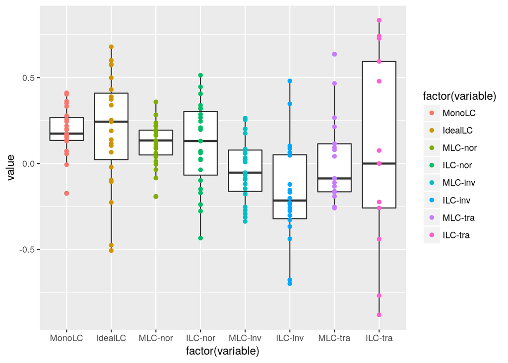

We can also sort the main LCs and view scatterplots to get a sense of how clustered the results are.

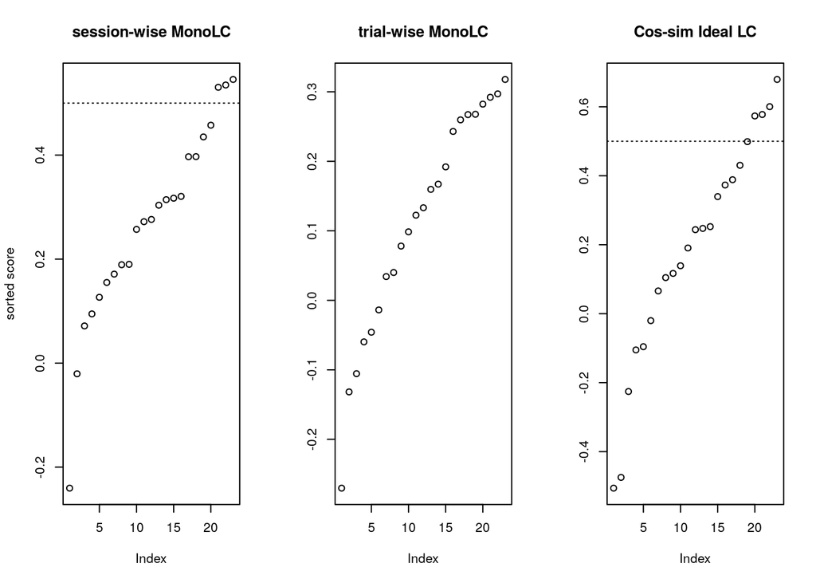

We can explore how the *monotonic* and *ideal* LCs relate to each other and to the following variables:

- Demographics, TB vs SMR, co-morbidities, BIS/BAS
- ADHD symptom self-reports
- IQ components
- Vigilance pre-test EEG measurement

We do this using a correlation matrix plot. Variables with their ranges lie on the diagonal. Over the diagonal are correlations of variable-pairs, and confidence intervals (in parentheses). Under the diagonal are loess-curve fits to the scatter plots of variable-pairs.

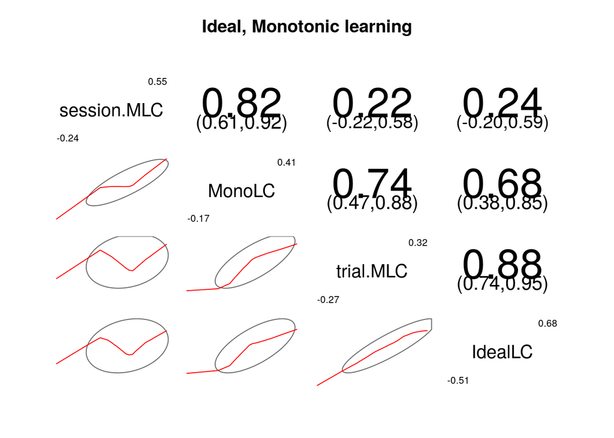

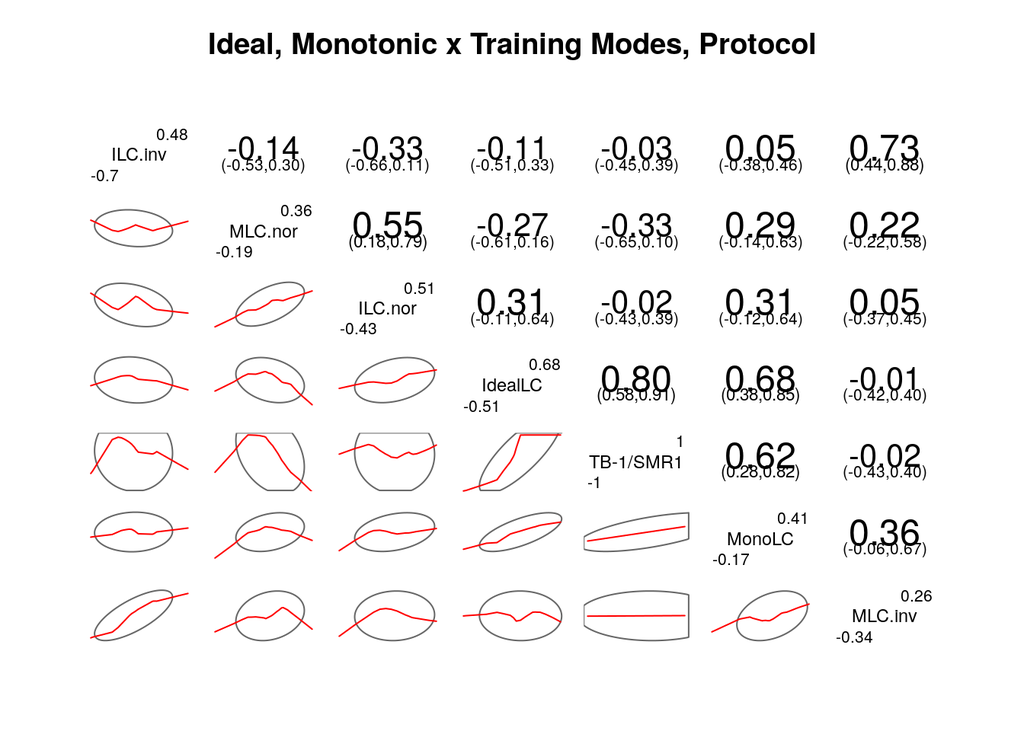

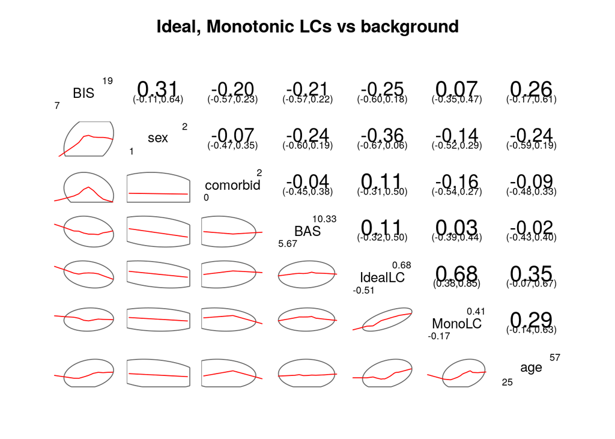

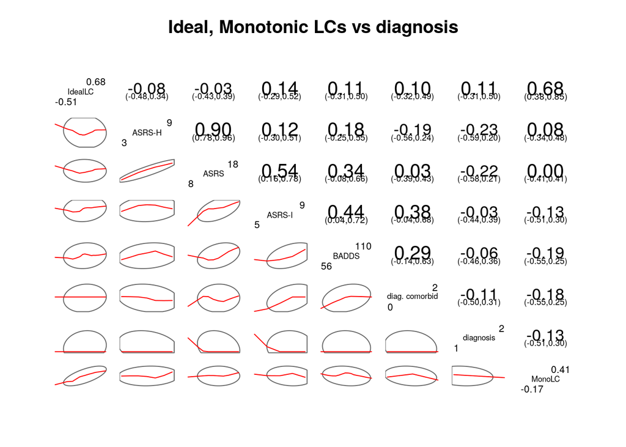

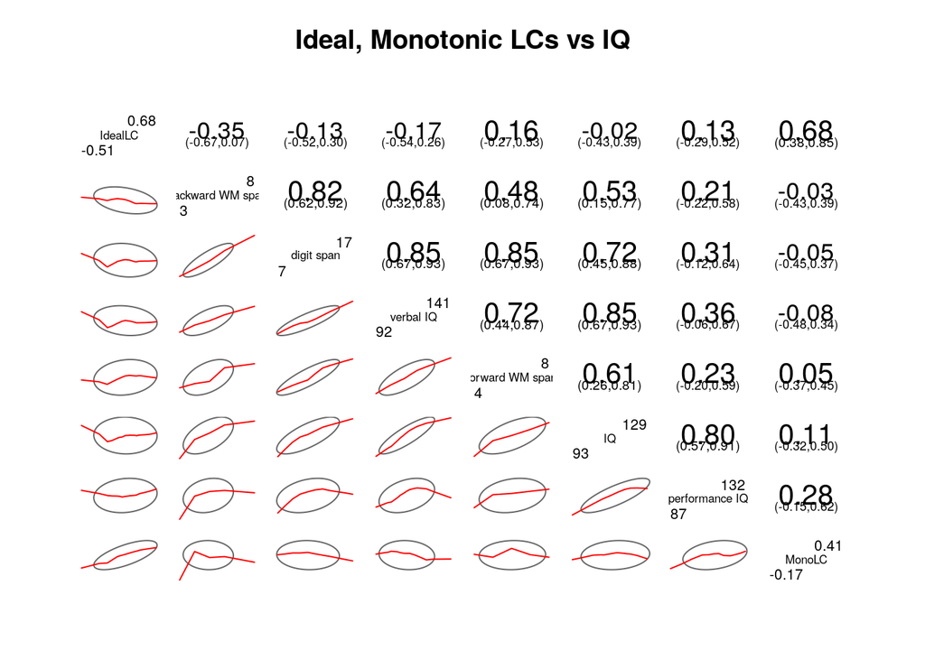

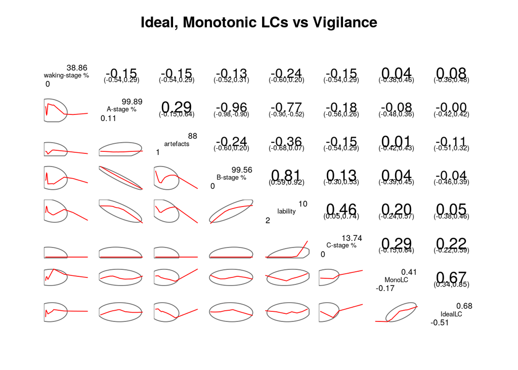

Let’s look a bit closer at the major finding from all these matrices. Protocol and LC correlate strongly. Some boxplots can show this a bit clearer.

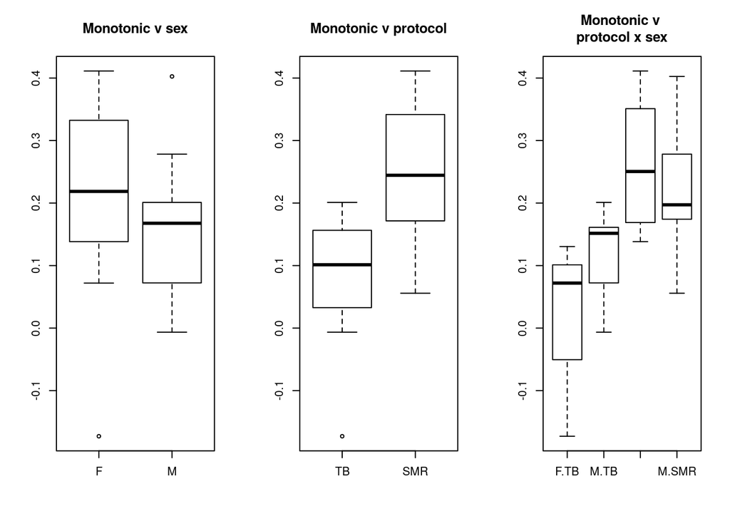

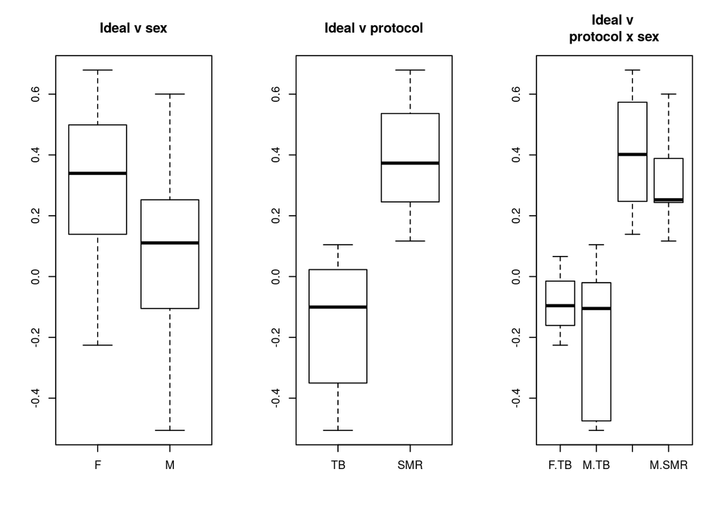

### Testing Monotonic LC

First, we want to know whether the group-wise Monotonic LC distribution was significantly biased, i.e. does the LC represent a consistent pattern of change across the group (do they improve)? The LC is based on calculations of Kendall’s tau. Under the null hypothesis of independence of X and Y, the sampling distribution of tau has an expected value of zero. Thus, group-wise null hypothesis can be that the distribution of LCs has a mean value close to zero. Because we have a small sample, we will not assume that the LC has a normal distribution, but instead use Wilcoxon’s non-parametric test.

```
##
##  Wilcoxon signed rank test
##
## data:  MonoLC[, 2]
## V = 264, p-value = 1.669e-05
## alternative hypothesis: true location is not equal to 0
## 95 percent confidence interval:
##  0.1365493 0.2513038
## sample estimates:
## (pseudo)median
##       0.193602
```

```
##
##  Wilcoxon signed rank test
##
## data:  MLC.nor[, 2]
## V = 251, p-value = 0.0002148
## alternative hypothesis: true location is not equal to 0
## 95 percent confidence interval:
##  0.07090617 0.17910577
## sample estimates:
## (pseudo)median
##      0.1283742
```

```
##
##  Wilcoxon signed rank test
##
## data:  MLC.inv[, 2]
## V = 102, p-value = 0.2861
## alternative hypothesis: true location is not equal to 0
## 95 percent confidence interval:
##  -0.12189276  0.04602613
## sample estimates:
## (pseudo)median
##    -0.03707805
```

```
##
##  Wilcoxon signed rank test
##
## data:  MLC.tra[, 2]
## V = 73, p-value = 0.89
## alternative hypothesis: true location is not equal to 0
## 95 percent confidence interval:
##  -0.1377130  0.1544351
## sample estimates:
## (pseudo)median
##    -0.01569792
```

Here we fit a linear regression model to Monotonic LCs to test the effect of protocol (TB, SMR). We also test the interaction of protocol by sex. A linear model is fitted to the LC for all modes together; and to each training mode (normal, inverse, transfer) separately.

```
##
## Call:
## lm(formula = MonoLC[, 2] ~ nfb$TB.1.SMR1)
##
## Residuals:
##       Min        1Q    Median        3Q       Max
## -0.249114 -0.078539 -0.003878  0.083676  0.161184
##
## Coefficients:
##               Estimate Std. Error t value Pr(>|t|)
## (Intercept)    0.16310    0.02411   6.766 1.08e-06 ***
## nfb$TB.1.SMR1  0.08696    0.02411   3.607  0.00165 **
## ---
## Signif. codes:  0 '***' 0.001 '**' 0.01 '*' 0.05 '.' 0.1 ' ' 1
##
## Residual standard error: 0.1101 on 21 degrees of freedom
## Multiple R-squared:  0.3826, Adjusted R-squared:  0.3532
## F-statistic: 13.01 on 1 and 21 DF,  p-value: 0.001655
```

```
##
## Call:
## lm(formula = MLC.nor[, 2] ~ nfb$TB.1.SMR1)
##
## Residuals:
##      Min       1Q   Median       3Q      Max
## -0.36714 -0.04086  0.01071  0.07307  0.18269
##
## Coefficients:
##               Estimate Std. Error t value Pr(>|t|)
## (Intercept)    0.13342    0.02644   5.046 5.38e-05 ***
## nfb$TB.1.SMR1 -0.04233    0.02644  -1.601    0.124
## ---
## Signif. codes:  0 '***' 0.001 '**' 0.01 '*' 0.05 '.' 0.1 ' ' 1
##
## Residual standard error: 0.1208 on 21 degrees of freedom
## Multiple R-squared:  0.1088, Adjusted R-squared:  0.06635
## F-statistic: 2.563 on 1 and 21 DF,  p-value: 0.1243
```

```
##
## Call:
## lm(formula = MLC.inv[, 2] ~ nfb$TB.1.SMR1)
##
## Residuals:
##       Min        1Q    Median        3Q       Max
## -0.299487 -0.124485 -0.009841  0.120302  0.301120
##
## Coefficients:
##                Estimate Std. Error t value Pr(>|t|)
## (Intercept)   -0.040071   0.040394  -0.992    0.332
## nfb$TB.1.SMR1 -0.003148   0.040394  -0.078    0.939
##
## Residual standard error: 0.1845 on 21 degrees of freedom
## Multiple R-squared:  0.0002892,  Adjusted R-squared:  -0.04732
## F-statistic: 0.006075 on 1 and 21 DF,  p-value: 0.9386
```

```
##
## Call:
## lm(formula = MLC.tra[, 2] ~ nfb[idx, ]$TB.1.SMR1)
##
## Residuals:
##      Min       1Q   Median       3Q      Max
## -0.31865 -0.20137 -0.05322  0.13761  0.56941
##
## Coefficients:
##                      Estimate Std. Error t value Pr(>|t|)
## (Intercept)           0.00453    0.06502    0.07    0.945
## nfb[idx, ]$TB.1.SMR1  0.06242    0.06502    0.96    0.352
##
## Residual standard error: 0.2562 on 15 degrees of freedom
## Multiple R-squared:  0.05789,    Adjusted R-squared:  -0.004915
## F-statistic: 0.9217 on 1 and 15 DF,  p-value: 0.3522
```

```
##
## Call:
## lm(formula = MonoLC[, 2] ~ nfb$TB.1.SMR1 * nfb$Female.2.Male2)
##
## Residuals:
##      Min       1Q   Median       3Q      Max
## -0.18280 -0.07142 -0.00780  0.07662  0.18096
##
## Coefficients:
##                                   Estimate Std. Error t value Pr(>|t|)
## (Intercept)                       0.152909   0.024973   6.123 6.92e-06 ***
## nfb$TB.1.SMR1                     0.090037   0.024973   3.605  0.00189 **
## nfb$Female.2.Male2                0.007927   0.012487   0.635  0.53311
## nfb$TB.1.SMR1:nfb$Female.2.Male2 -0.018600   0.012487  -1.490  0.15274
## ---
## Signif. codes:  0 '***' 0.001 '**' 0.01 '*' 0.05 '.' 0.1 ' ' 1
##
## Residual standard error: 0.1094 on 19 degrees of freedom
## Multiple R-squared:  0.4485, Adjusted R-squared:  0.3614
## F-statistic:  5.15 on 3 and 19 DF,  p-value: 0.008956
```

```
##
## Call:
## lm(formula = MLC.nor[, 2] ~ nfb$TB.1.SMR1 * nfb$Female.2.Male2)
##
## Residuals:
##       Min        1Q    Median        3Q       Max
## -0.244120 -0.049849  0.007843  0.087922  0.133736
##
## Coefficients:
##                                  Estimate Std. Error t value Pr(>|t|)
## (Intercept)                       0.11766    0.02500   4.706 0.000154 ***
## nfb$TB.1.SMR1                    -0.03349    0.02500  -1.339 0.196213
## nfb$Female.2.Male2                0.01942    0.01250   1.554 0.136801
## nfb$TB.1.SMR1:nfb$Female.2.Male2 -0.02979    0.01250  -2.383 0.027759 *
## ---
## Signif. codes:  0 '***' 0.001 '**' 0.01 '*' 0.05 '.' 0.1 ' ' 1
##
## Residual standard error: 0.1095 on 19 degrees of freedom
## Multiple R-squared:  0.3368, Adjusted R-squared:  0.2321
## F-statistic: 3.216 on 3 and 19 DF,  p-value: 0.04609
```

```
##
## Call:
## lm(formula = MLC.inv[, 2] ~ nfb$TB.1.SMR1 * nfb$Female.2.Male2)
##
## Residuals:
##      Min       1Q   Median       3Q      Max
## -0.25586 -0.15569 -0.01609  0.10494  0.37262
##
## Coefficients:
##                                   Estimate Std. Error t value Pr(>|t|)
## (Intercept)                      -0.049719   0.043255  -1.149    0.265
## nfb$TB.1.SMR1                     0.003374   0.043255   0.078    0.939
## nfb$Female.2.Male2                0.013827   0.021628   0.639    0.530
## nfb$TB.1.SMR1:nfb$Female.2.Male2 -0.018515   0.021628  -0.856    0.403
##
## Residual standard error: 0.1895 on 19 degrees of freedom
## Multiple R-squared:  0.0458, Adjusted R-squared:  -0.1049
## F-statistic: 0.304 on 3 and 19 DF,  p-value: 0.8222
```

```
##
## Call:
## lm(formula = MLC.tra[, 2] ~ nfb[idx, ]$TB.1.SMR1 * nfb[idx, ]$Female.2.Male2)
##
## Residuals:
##      Min       1Q   Median       3Q      Max
## -0.31766 -0.19809 -0.05649  0.13434  0.56884
##
## Coefficients:
##                                                  Estimate Std. Error
## (Intercept)                                     0.0044231  0.0708237
## nfb[idx, ]$TB.1.SMR1                            0.0623172  0.0708237
## nfb[idx, ]$Female.2.Male2                      -0.0010139  0.0354118
## nfb[idx, ]$TB.1.SMR1:nfb[idx, ]$Female.2.Male2  0.0006226  0.0354118
##                                                t value Pr(>|t|)
## (Intercept)                                      0.062    0.951
## nfb[idx, ]$TB.1.SMR1                             0.880    0.395
## nfb[idx, ]$Female.2.Male2                       -0.029    0.978
## nfb[idx, ]$TB.1.SMR1:nfb[idx, ]$Female.2.Male2   0.018    0.986
##
## Residual standard error: 0.2752 on 13 degrees of freedom
## Multiple R-squared:  0.05796,    Adjusted R-squared:  -0.1594
## F-statistic: 0.2666 on 3 and 13 DF,  p-value: 0.8483
```

```
##
## Call:
## lm(formula = ssn.trl.MLC[, 2] ~ nfb$TB.1.SMR1 * nfb$Female.2.Male2)
##
## Residuals:
##     Min      1Q  Median      3Q     Max
## -0.3305 -0.1250  0.0076  0.1278  0.2466
##
## Coefficients:
##                                  Estimate Std. Error t value Pr(>|t|)
## (Intercept)                       0.24173    0.04302   5.620 2.03e-05 ***
## nfb$TB.1.SMR1                     0.06236    0.04302   1.450    0.163
## nfb$Female.2.Male2                0.02631    0.02151   1.223    0.236
## nfb$TB.1.SMR1:nfb$Female.2.Male2 -0.01835    0.02151  -0.853    0.404
## ---
## Signif. codes:  0 '***' 0.001 '**' 0.01 '*' 0.05 '.' 0.1 ' ' 1
##
## Residual standard error: 0.1885 on 19 degrees of freedom
## Multiple R-squared:  0.1427, Adjusted R-squared:  0.007375
## F-statistic: 1.054 on 3 and 19 DF,  p-value: 0.3916
```

```
##
## Call:
## lm(formula = trials.MLC[, 2] ~ nfb$TB.1.SMR1 * nfb$Female.2.Male2)
##
## Residuals:
##      Min       1Q   Median       3Q      Max
## -0.23344 -0.06086  0.02300  0.04677  0.17001
##
## Coefficients:
##                                  Estimate Std. Error t value Pr(>|t|)
## (Intercept)                       0.06409    0.02325   2.757   0.0125 *
## nfb$TB.1.SMR1                     0.11771    0.02325   5.063  6.9e-05 ***
## nfb$Female.2.Male2               -0.01046    0.01162  -0.900   0.3796
## nfb$TB.1.SMR1:nfb$Female.2.Male2 -0.01885    0.01162  -1.622   0.1213
## ---
## Signif. codes:  0 '***' 0.001 '**' 0.01 '*' 0.05 '.' 0.1 ' ' 1
##
## Residual standard error: 0.1019 on 19 degrees of freedom
## Multiple R-squared:  0.656,  Adjusted R-squared:  0.6017
## F-statistic: 12.08 on 3 and 19 DF,  p-value: 0.0001185
```

### Testing Ideal LC

We also test whether the group-wise Ideal LC distribution was significantly biased, i.e. do they learn a skill? As before, we use Wilcoxon’s non-parametric test.

```
##
##  Wilcoxon signed rank test
##
## data:  IdealLC[, 2]
## V = 222, p-value = 0.009146
## alternative hypothesis: true location is not equal to 0
## 95 percent confidence interval:
##  0.05686848 0.34505099
## sample estimates:
## (pseudo)median
##      0.2179567
```

```
##
##  Wilcoxon signed rank test
##
## data:  ILC.nor[, 2]
## V = 202, p-value = 0.05223
## alternative hypothesis: true location is not equal to 0
## 95 percent confidence interval:
##  -0.004961417  0.233522425
## sample estimates:
## (pseudo)median
##      0.1162001
```

```
##
##  Wilcoxon signed rank test
##
## data:  ILC.inv[, 2]
## V = 50, p-value = 0.01147
## alternative hypothesis: true location is not equal to 0
## 95 percent confidence interval:
##  -0.30617625 -0.05318447
## sample estimates:
## (pseudo)median
##     -0.1866923
```

```
##
##  Wilcoxon signed rank test with continuity correction
##
## data:  ILC.tra[, 2]
## V = 37, p-value = 0.7557
## alternative hypothesis: true location is not equal to 0
## 95 percent confidence interval:
##  -0.4019551  0.6098858
## sample estimates:
## (pseudo)median
##      0.1036851
```

Next we fit linear regression models to the Ideal LCs. First four are effect of protocol only, next four are interaction effect of protocol x sex. Data from all modes is tested together, then each training mode is tested separately.

```
##
## Call:
## lm(formula = IdealLC[, 2] ~ nfb$TB.1.SMR1)
##
## Residuals:
##      Min       1Q   Median       3Q      Max
## -0.34884 -0.13123  0.01178  0.16680  0.30255
##
## Coefficients:
##               Estimate Std. Error t value Pr(>|t|)
## (Intercept)    0.10976    0.04324   2.539   0.0191 *
## nfb$TB.1.SMR1  0.26690    0.04324   6.173    4e-06 ***
## ---
## Signif. codes:  0 '***' 0.001 '**' 0.01 '*' 0.05 '.' 0.1 ' ' 1
##
## Residual standard error: 0.1975 on 21 degrees of freedom
## Multiple R-squared:  0.6447, Adjusted R-squared:  0.6278
## F-statistic:  38.1 on 1 and 21 DF,  p-value: 4.004e-06
```

```
##
## Call:
## lm(formula = ILC.nor[, 2] ~ nfb$TB.1.SMR1)
##
## Residuals:
##      Min       1Q   Median       3Q      Max
## -0.54783 -0.17036  0.02791  0.19439  0.41083
##
## Coefficients:
##               Estimate Std. Error t value Pr(>|t|)
## (Intercept)    0.10854    0.05632   1.927   0.0676 .
## nfb$TB.1.SMR1 -0.00563    0.05632  -0.100   0.9213
## ---
## Signif. codes:  0 '***' 0.001 '**' 0.01 '*' 0.05 '.' 0.1 ' ' 1
##
## Residual standard error: 0.2573 on 21 degrees of freedom
## Multiple R-squared:  0.0004756,  Adjusted R-squared:  -0.04712
## F-statistic: 0.009993 on 1 and 21 DF,  p-value: 0.9213
```

```
##
## Call:
## lm(formula = ILC.inv[, 2] ~ nfb$TB.1.SMR1)
##
## Residuals:
##      Min       1Q   Median       3Q      Max
## -0.53337 -0.13475 -0.02898  0.23173  0.64527
##
## Coefficients:
##               Estimate Std. Error t value Pr(>|t|)
## (Intercept)   -0.17543    0.07154  -2.452   0.0235 *
## nfb$TB.1.SMR1 -0.01054    0.07154  -0.147   0.8843
## ---
## Signif. codes:  0 '***' 0.001 '**' 0.01 '*' 0.05 '.' 0.1 ' ' 1
##
## Residual standard error: 0.3126 on 20 degrees of freedom
##   (1 observation deleted due to missingness)
## Multiple R-squared:  0.001085,   Adjusted R-squared:  -0.04886
## F-statistic: 0.02172 on 1 and 20 DF,  p-value: 0.8843
```

```
##
## Call:
## lm(formula = ILC.tra[, 2] ~ nfb[idx, ]$TB.1.SMR1)
##
## Residuals:
##      Min       1Q   Median       3Q      Max
## -0.96250 -0.34082 -0.08262  0.51128  0.75444
##
## Coefficients:
##                      Estimate Std. Error t value Pr(>|t|)
## (Intercept)           0.03464    0.23058   0.150    0.883
## nfb[idx, ]$TB.1.SMR1  0.04798    0.23058   0.208    0.839
##
## Residual standard error: 0.5999 on 11 degrees of freedom
## Multiple R-squared:  0.003921,   Adjusted R-squared:  -0.08663
## F-statistic: 0.0433 on 1 and 11 DF,  p-value: 0.839
```

```
##
## Call:
## lm(formula = IdealLC[, 2] ~ nfb$TB.1.SMR1 * nfb$Female.2.Male2)
##
## Residuals:
##     Min      1Q  Median      3Q     Max
## -0.3057 -0.1491 -0.0106  0.1598  0.3049
##
## Coefficients:
##                                   Estimate Std. Error t value Pr(>|t|)
## (Intercept)                       0.109912   0.045963   2.391   0.0273 *
## nfb$TB.1.SMR1                     0.252658   0.045963   5.497 2.65e-05 ***
## nfb$Female.2.Male2               -0.024959   0.022981  -1.086   0.2910
## nfb$TB.1.SMR1:nfb$Female.2.Male2  0.003823   0.022981   0.166   0.8696
## ---
## Signif. codes:  0 '***' 0.001 '**' 0.01 '*' 0.05 '.' 0.1 ' ' 1
##
## Residual standard error: 0.2014 on 19 degrees of freedom
## Multiple R-squared:  0.6658, Adjusted R-squared:  0.613
## F-statistic: 12.62 on 3 and 19 DF,  p-value: 9.072e-05
```

```
##
## Call:
## lm(formula = ILC.nor[, 2] ~ nfb$TB.1.SMR1 * nfb$Female.2.Male2)
##
## Residuals:
##      Min       1Q   Median       3Q      Max
## -0.46003 -0.14315  0.01917  0.19003  0.33553
##
## Coefficients:
##                                  Estimate Std. Error t value Pr(>|t|)
## (Intercept)                       0.08094    0.05695   1.421    0.171
## nfb$TB.1.SMR1                    -0.01567    0.05695  -0.275    0.786
## nfb$Female.2.Male2               -0.01068    0.02848  -0.375    0.712
## nfb$TB.1.SMR1:nfb$Female.2.Male2 -0.04580    0.02848  -1.608    0.124
##
## Residual standard error: 0.2495 on 19 degrees of freedom
## Multiple R-squared:  0.1494, Adjusted R-squared:  0.01505
## F-statistic: 1.112 on 3 and 19 DF,  p-value: 0.3688
```

```
##
## Call:
## lm(formula = ILC.inv[, 2] ~ nfb$TB.1.SMR1 * nfb$Female.2.Male2)
##
## Residuals:
##      Min       1Q   Median       3Q      Max
## -0.58077 -0.16663 -0.01793  0.21484  0.57609
##
## Coefficients:
##                                   Estimate Std. Error t value Pr(>|t|)
## (Intercept)                      -0.178067   0.076436  -2.330   0.0317 *
## nfb$TB.1.SMR1                    -0.001649   0.076436  -0.022   0.9830
## nfb$Female.2.Male2                0.024871   0.038218   0.651   0.5234
## nfb$TB.1.SMR1:nfb$Female.2.Male2 -0.015484   0.038218  -0.405   0.6901
## ---
## Signif. codes:  0 '***' 0.001 '**' 0.01 '*' 0.05 '.' 0.1 ' ' 1
##
## Residual standard error: 0.3253 on 18 degrees of freedom
##   (1 observation deleted due to missingness)
## Multiple R-squared:  0.02632,    Adjusted R-squared:  -0.136
## F-statistic: 0.1622 on 3 and 18 DF,  p-value: 0.9204
```

```
##
## Call:
## lm(formula = ILC.tra[, 2] ~ nfb[idx, ]$TB.1.SMR1 * nfb[idx, ]$Female.2.Male2)
##
## Residuals:
##      Min       1Q   Median       3Q      Max
## -0.90013 -0.27844 -0.02024  0.53605  0.81309
##
## Coefficients: (1 not defined because of singularities)
##                                                Estimate Std. Error t value
## (Intercept)                                     0.08922    0.26986   0.331
## nfb[idx, ]$TB.1.SMR1                            0.01679    0.24984   0.067
## nfb[idx, ]$Female.2.Male2                       0.04288    0.09765   0.439
## nfb[idx, ]$TB.1.SMR1:nfb[idx, ]$Female.2.Male2       NA         NA      NA
##                                                Pr(>|t|)
## (Intercept)                                       0.748
## nfb[idx, ]$TB.1.SMR1                              0.948
## nfb[idx, ]$Female.2.Male2                         0.670
## nfb[idx, ]$TB.1.SMR1:nfb[idx, ]$Female.2.Male2       NA
##
## Residual standard error: 0.6232 on 10 degrees of freedom
## Multiple R-squared:  0.02276,    Adjusted R-squared:  -0.1727
## F-statistic: 0.1165 on 2 and 10 DF,  p-value: 0.8912
```

## Other data

*Work in Progress - to be continued…*

We would also like to look at individual band powers from per-session baselines.

We can also consider comparing some other data that takes a bit more work to include:

- IAPF (but prior work relating this to learning outcome was for alpha-power training, which CENT was not)
- Pre-test theta/beta bandpowers (but protocols were assigned based on this, so it is confounded)
- Pittsburgh Sleep Quality Index (PSQI) (asked 4 times throughout training)
- Placebo survey (asked 3 times throughout training)
- T.O.V.A. variables, pre and/or post (already thoroughly investigated?)
- Trainer-patient interaction self-reports (not validated instruments)

## Other LC methods - temporal difference

Another way to examine signal change without fitting a model is to look at autocorrelation or lagged difference.

*Work in Progress - to be continued…*